# Evaluating cell scoring metrics

Ally Hawkins

2026-03-26

In this notebook, we look at ways to measure variation in cell scores across metaprograms. For each value of k, we want to summarize how many metaprograms show variation in the scores across the original samples used to construct the metaprograms.

Scores are calculated by taking the dot product between the top 200 gene weights and the quantile normalized counts for those genes. Each cell will have a single score for each metaprogram.

To measure if a metaprogram shows variation, we will compare the observed coefficient of variation (CV) and variance to a background distribution. This background distribution was calculated by shuffling the gene x metaprogram matrix, pulling the top 200 genes and re-calculating the scores. Each metaprogram will have a unique background distribution.

```r
library(ggplot2)

# load libraries that we need for the linear mixed-effect model later
library(lme4)
library(lmerTest)

# Set default ggplot theme
theme_set(
  theme_bw()
)

set.seed(2026)
```

```r
# metaprograms results directory
results_dir <- here::here("ews-nf-out", "metaprograms")

# params we are looking at in this particular notebook
# use these to construct the file paths
n_metaprograms <- seq(5, 15, 1)

# directories with metaprogram results
# one directory per n_metaprogram
metaprogram_output_dirs <- file.path(
  results_dir,
  glue::glue("metaprograms-{n_metaprograms}_cnmf-5-10-15_filtered")
)

# path to files with the observed scores
scores_files <- file.path(metaprogram_output_dirs, "metaprogram_scores.tsv") |>
  purrr::set_names(sprintf("k_%02d", n_metaprograms))

# path to files with the background scores
background_files <- file.path(metaprogram_output_dirs, "background_scores.tsv") |>
  purrr::set_names(sprintf("k_%02d", n_metaprograms))

# significance value so we don't accidentally mis type it
sig_value <- 0.05
```

```r
# observed scores
# this includes one score for each cell for each metaprogram
scores_df <- scores_files |>
  purrr::map(readr::read_tsv, col_types = list(.default = "c", mp_score = "d")) |>
  dplyr::bind_rows(.id = "n_metaprograms")

# background scores
# instead of one score for each cell we have the mean and sum of squared deviations
# for each sample and metaprogram
# this is repeated across 1000 replicates
background_df <- background_files |>
  purrr::map(readr::read_tsv, col_types = list(.default = "d", metaprogram = "c", unique_id = "c")) |>
  dplyr::bind_rows(.id = "n_metaprograms")
```

## Functions

We’ll use these functions to compute the pvalue and plot the permutation results later on.

```r
# function to compute the pvalue
compute_var_pvalue <- function(background_df, obs_df, stat_column, nreps) {

  # join observed values with background values
  background_df |>
    dplyr::left_join(
      dplyr::rename(obs_df, obs_value = {{ stat_column }}),
      by = c("n_metaprograms", "metaprogram")
    ) |>
    # indicator column for if background >= observation
    dplyr::mutate(greater_than_obs = {{ stat_column }} >= obs_value) |>
    dplyr::summarize(
      obs_value = unique(obs_value),
      overall_pvalue = (sum(greater_than_obs) + 1) / (nreps + 1),
      .by = c("n_metaprograms", "metaprogram")
    ) |>
    # add in adjusted pvalue
    dplyr::mutate(
      overall_adj_pvalue = p.adjust(overall_pvalue, method = "BH"),
      is_significant = overall_adj_pvalue <= sig_value
    )
}

# function to plot permutation results compared to background
plot_permutation_results <- function(background_df, pvalue_df, x_axis, y_axis){

  ggplot(background_df, aes(x = {{ x_axis }}, y = {{ y_axis }})) +
  ggforce::geom_sina(
    color = "gray",
    alpha = 0.1
  ) +
  geom_point(
    data = pvalue_df,
    aes(
      x = {{ x_axis }},
      y = {{ y_axis }},
      color = is_significant
    ),
    size  = 3,
    shape = 18  # diamond
  ) +
  scale_color_manual(values = c(`TRUE` = "red", `FALSE` = "blue")) +
  theme(
    axis.text.x = element_text(angle = 90)
  )

}
```

## Compute CV and Variance

First we will approximate the CV and variance for the background distribution for each metaprogram. To do this, we’ll use Chan’s algorithm to approximate the global values from the individual sub-populations (samples in this case).

```r
# calculate CV for each metaprogram for each sample using Chan's algorithm
# get both CV and var
global_background_df <- background_df |>
  dplyr::summarize(
    n_total = sum(num_cells),
    global_mean = sum(num_cells * mean_mp_score) / sum(num_cells),
    M2_total = sum(M2) + sum(num_cells * (mean_mp_score - global_mean)^2),
    score_var = M2_total / (n_total - 1),
    global_sd  = sqrt(score_var),
    score_cv  = (global_sd / global_mean),
    .by = c("n_metaprograms", "metaprogram", "replicate")
  )
```

We’ll then get the CV and variance for the observed values. We can do this by directly calculating the values from the individual cells or using Chan’s approximation.

```r
# calculate variance and CV for each sample without using Chan's
# we'll compare this to the value you would get if you used Chan's to confirm that the CV/variance is the same
var_df <- scores_df |>
  dplyr::summarize(
    score_var = var(mp_score, na.rm = TRUE),
    score_cv = sqrt(score_var) / mean(mp_score),
    .by = c("n_metaprograms", "metaprogram")
  ) |>
  dplyr::ungroup()

# now use Chan's to first get the variance for all cells in a sample
# then get variance and CV for all samples for a given metaprogram
chans_var_df <- scores_df |>
  # first calculate the variance for each sample and each metaprogram
  dplyr::summarize(
    num_cells = length(unique(barcodes)),
    mean_mp_score = mean(mp_score),
    M2 = sum((mp_score - mean_mp_score)^2),
    .by = c("n_metaprograms", "metaprogram", "unique_id")
  ) |>
  # now get the global values for each k/metaprogram
  dplyr::summarize(
    n_total = sum(num_cells),
    global_mean = sum(num_cells * mean_mp_score) / sum(num_cells),
    M2_total = sum(M2) + sum(num_cells * (mean_mp_score - sum(num_cells * mean_mp_score) / sum(num_cells))^2),
    .by = c("n_metaprograms", "metaprogram")
  ) |>
  dplyr::mutate(
    score_var = M2_total / (n_total - 1),
    global_sd  = sqrt(score_var),
    score_cv  = (global_sd / global_mean)
  )
```

Let’s check to see if both ways give us the same results.

```r
chans_cv <- chans_var_df$score_cv
reg_cv <- var_df$score_cv

all.equal(chans_cv, reg_cv)
```

```
[1] TRUE
```

As expected, the values calculated using Chan’s formula are equivalent to directly calculating the CV of the entire population. So it doesn’t matter which calculation we use when comparing observed to the background.

## Plot CV

Below we look at the observed CV compared to the background for each metaprogram. Red dots indicate metaprograms that have a CV that is significantly greater than what would be observed by random chance.

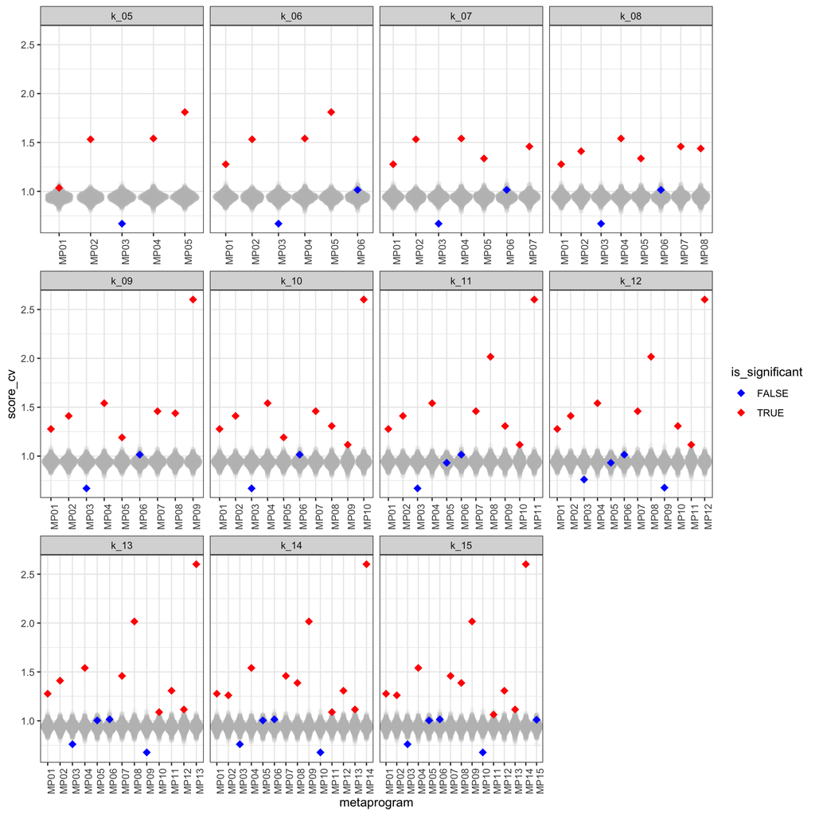

```r
cv_pvalue_df <- compute_var_pvalue(global_background_df, var_df, score_cv, 1000) |>
  dplyr::rename(score_cv = obs_value)

plot_permutation_results(global_background_df, cv_pvalue_df, metaprogram, score_cv) +
  facet_wrap(
    vars(n_metaprograms),
    scales = "free_x",
    ncol = 4
  )
```

A small side note is that MP03 is the “noise” metaprogram that we are consistently seeing with low coherence. It looks like the variation of this metaprogram is low across the board.

## Plot Variance

We can also directly look at variance.

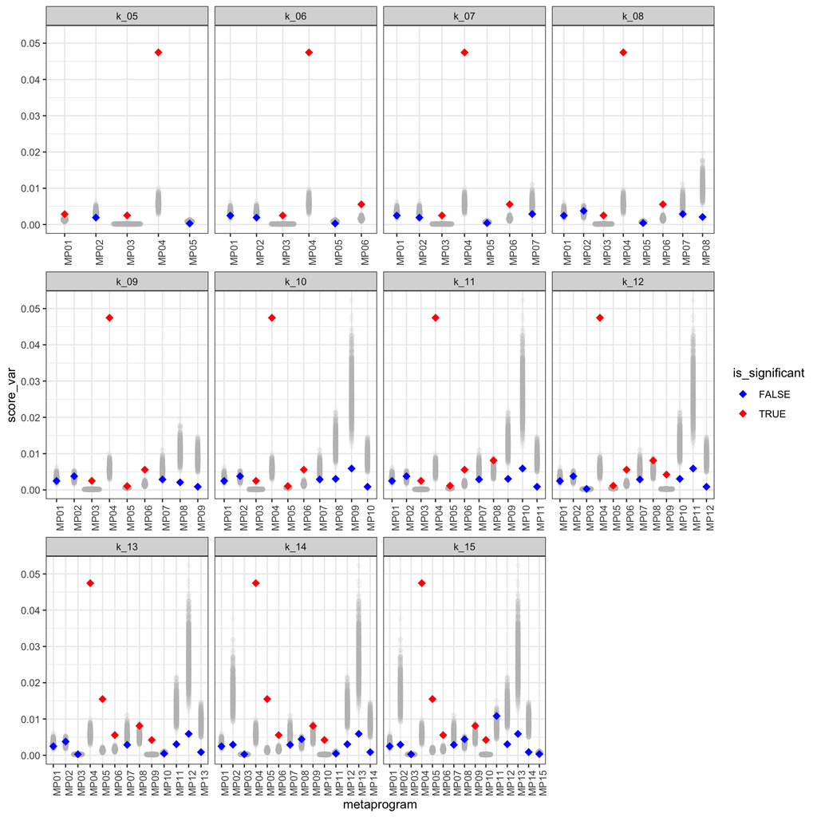

```r
var_pvalue_df <- compute_var_pvalue(global_background_df, var_df, score_var, 1000) |>
  dplyr::rename(score_var = obs_value)

plot_permutation_results(global_background_df, var_pvalue_df, metaprogram, score_var) +
  facet_wrap(
    vars(n_metaprograms),
    scales = "free_x",
    ncol = 4
  )
```

Here the background distributions vary from metaprogram to metaprogram. We see some observed values that are below the background and if we used a two sided test might show up as significant. However, we are only interested in those that have higher variance than background.

It’s interesting that the CV background distributions are so uniform but the variance distributions are more variable. Could the variance be directly impacted by mean gene expression? Let’s look at the mean expression to see how those distributions look.

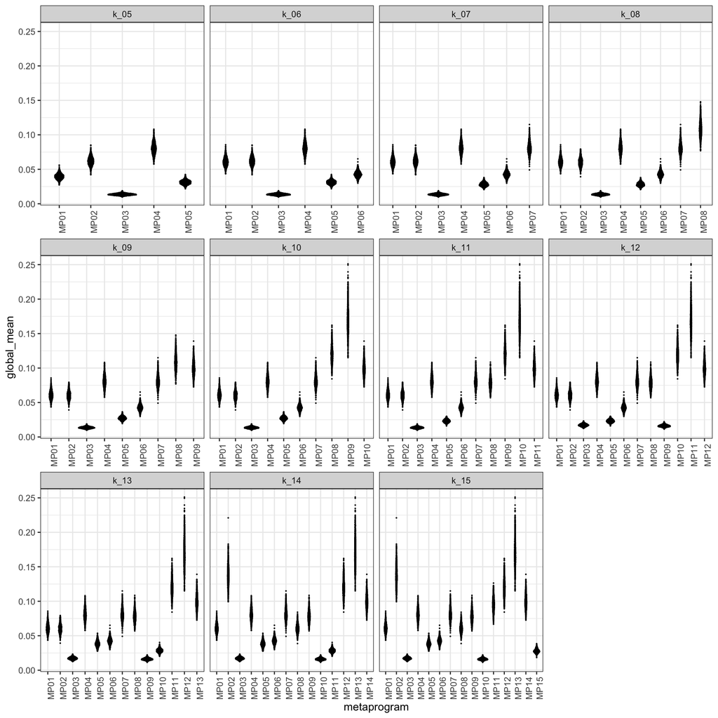

```r
ggplot(global_background_df, aes(y = global_mean, x = metaprogram)) +
  ggforce::geom_sina(size = 0.1) +
  facet_wrap(vars(n_metaprograms), scales = "free_x") +
  theme(
    axis.text.x = element_text(angle = 90)
  )
```

These distributions very much mirror what we see for the variance, where metaprograms like MP09 have high mean and high variance. In contrast, metaprograms with low mean expression have low variance. Let’s double check this by looking at the correlation of these two values.

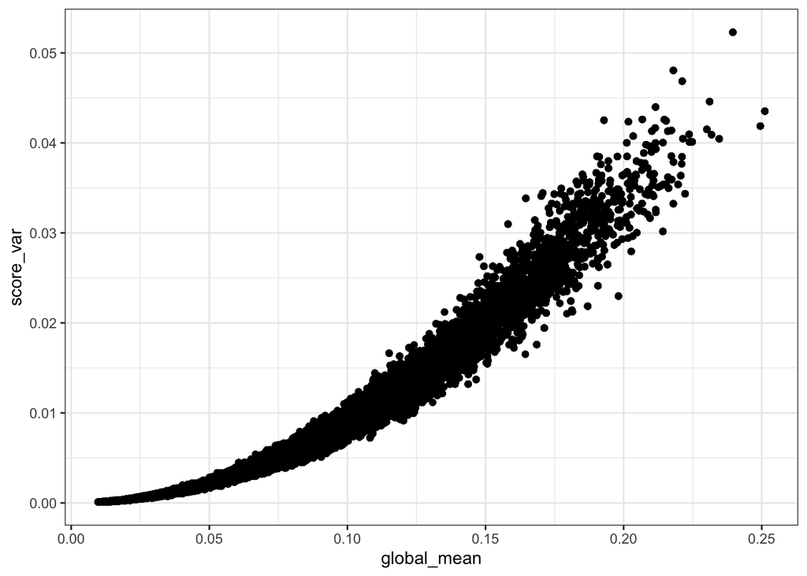

```r
ggplot(global_background_df, aes(x = global_mean, y= score_var)) +
  geom_point()
```

Yup, as expected, there’s a direct relationship between the mean expression and variance. What about with the CV?

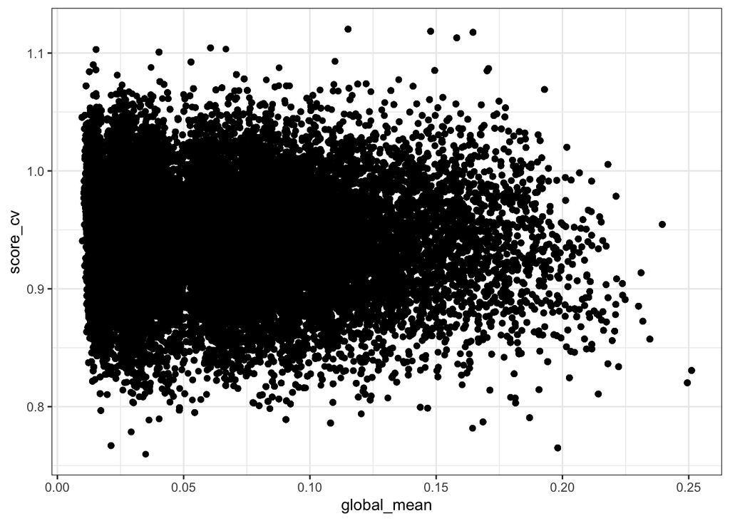

```r
ggplot(global_background_df, aes(x = global_mean, y= score_cv)) +
  geom_point()
```

There doesn’t appear to be a clear relationship here. I think this is a good argument to use the CV.

## Proportion of metaprograms with significant CV

If we look at the proportion of metaprograms with a CV that’s significant, which values of k get prioritized?

```r
cv_pvalue_df |>
  dplyr::mutate(
    is_significant = overall_adj_pvalue <= sig_value
  ) |>
  dplyr::summarize(
    num_mps = length(metaprogram),
    proportion_cv_sig = sum(is_significant)/num_mps,
    .by = "n_metaprograms"
  ) |>
  dplyr::arrange(desc(proportion_cv_sig))
```

| n_metaprograms | num_mps | proportion_cv_sig |
| --- | --- | --- |
| k_05 | 5 | 0.8000000 |
| k_10 | 10 | 0.8000000 |
| k_09 | 9 | 0.7777778 |
| k_08 | 8 | 0.7500000 |
| k_11 | 11 | 0.7272727 |
| k_07 | 7 | 0.7142857 |
| k_14 | 14 | 0.7142857 |
| k_13 | 13 | 0.6923077 |
| k_06 | 6 | 0.6666667 |
| k_12 | 12 | 0.6666667 |

[output cut: 1 more lines]

It looks like k=5 and k=10 are tied with 80% of metaprograms. It’s nice to see a metric that doesn’t appear to be dictated by the value of k. I think this is something we could use to influence our decision of k.

## Sample metadata

One thing we are curious about is if the scores that we observe are higher or lower in some samples than other. For example, do we see a difference in scores for some metaprograms in samples from primary or metastatic tumors?

We shouldn’t use this information to decide k, but it can be helpful summary information to see if samples from different tumor stages show higher or lower scores for a metaprogram.

```r
# TODO: This path is relative to where my ScPCA-admin repo is stored
# Before we can do anything with this outside of this notebook we'll have to save it to this repo in someway
sample_metadata_file <- "../../ScPCA-admin/sample_info/bailey_cillo/sample-metadata.tsv"
sample_df <- readr::read_tsv(sample_metadata_file, col_types = "c")
```

To see if there are any different scores between samples based on type, we’ll first get the mean score for each metaprogram across all cells for each sample. This should account for any expected relationship in gene expression among cells from the same sample and minimize the potential for inflating our statistics.

```r
mean_scores_df <- scores_df |>
  dplyr::summarize(
    mean_mp_score = mean(mp_score),
    .by = c("unique_id", "metaprogram", "n_metaprograms")
  ) |>
  dplyr::mutate(
    scpca_sample_id = stringr::word(unique_id, -1, sep = "-"),
    # first log transform
    log_mean_mp_score = log(mean_mp_score)
  ) |>
  # z-score the log scores within each k and metaprogram
  # use these for plotting
  dplyr::mutate(
    scpca_sample_id = stringr::word(unique_id, -1, sep = "-"),
    zscore_mean_mp_score = scale(log_mean_mp_score),
    .by = c("metaprogram", "n_metaprograms")
  ) |>
  # add in the sample metadata including disease timing and patient information
  dplyr::left_join(dplyr::select(sample_df, c("scpca_sample_id", "participant_id", "disease_timing")), by = c("scpca_sample_id"))
```

We will look at the `disease_timing` column which groups samples into primary, metastasis and recurrence. Let’s start by just plotting the distributions.

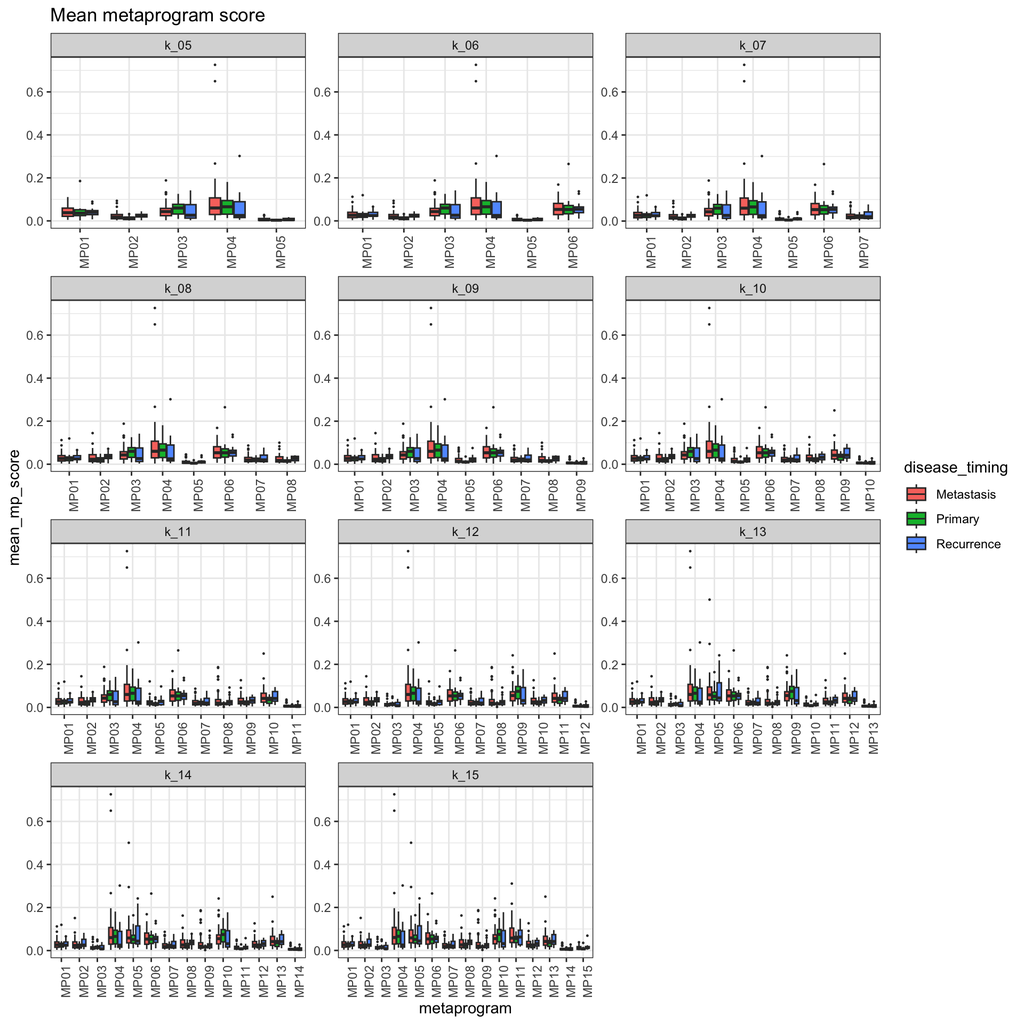

```r
ggplot(mean_scores_df, aes(x = metaprogram, y = mean_mp_score, fill = disease_timing)) +
  geom_boxplot(outlier.size = 0.2) +
  facet_wrap(vars(n_metaprograms),
             scales = "free",
             ncol = 3) +
  theme(
    axis.text.x = element_text(angle = 90)
  ) +
  labs(
    title = "Mean metaprogram score"
  )
```

It looks like a lot of these scores are skewed to be closer to 0. Let’s look at the z-score of these scores, calculated for each metaprogram and value of k.

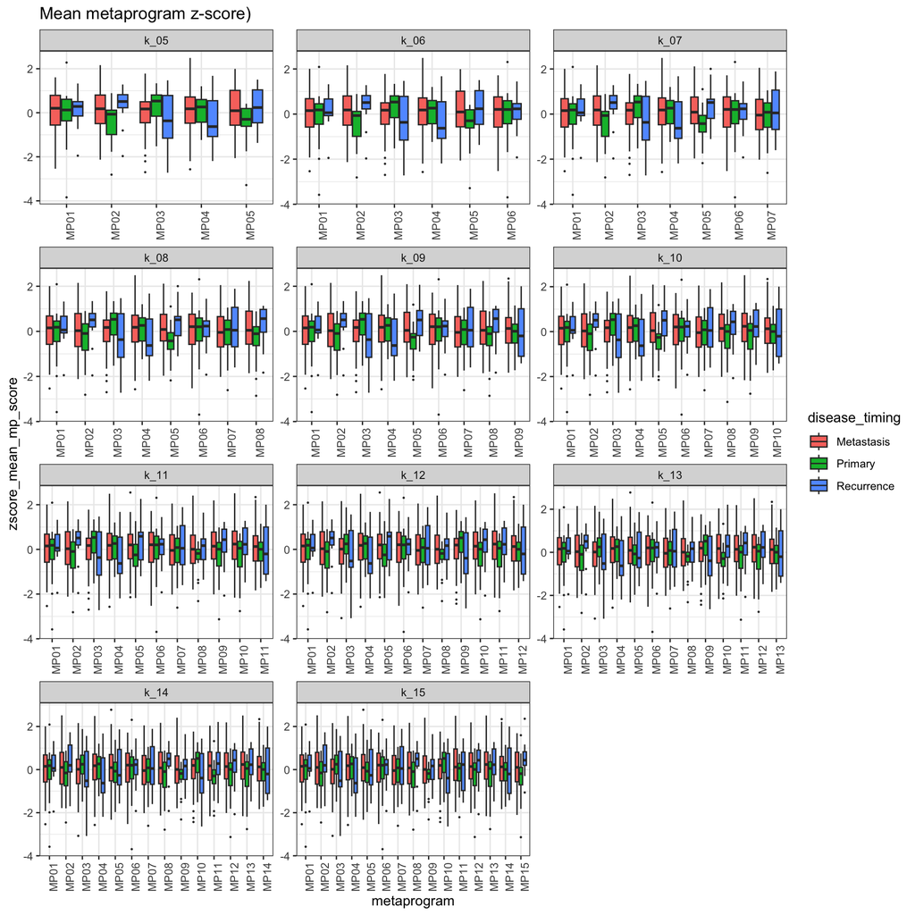

```r
ggplot(mean_scores_df, aes(x = metaprogram, y = zscore_mean_mp_score, fill = disease_timing)) +
  geom_boxplot(outlier.size = 0.2) +
  facet_wrap(vars(n_metaprograms),
             scales = "free",
             ncol = 3) +
  theme(
    axis.text.x = element_text(angle = 90)
  ) +
  labs(
    title = "Mean metaprogram z-score)"
  )
```

Generally most of the metaprograms have similar distributions of scores across sample types. There may be some differences in the recurrent samples where we see either higher scores (MP05 and MP02 for most lower values of k) or lower scores (MP04).

Let’s see if any of these distributions are significantly different from the others. Since we have three groups, we will use the Kruskal-Wallis test to determine if samples from different disease timings are significantly different than other samples for each metaprogram.

```r
# run Kw test on each metaprogram for each value of k
# within each metaprogram test if there are differences in the distribution of scores
# between samples from different disease timing
kruskal_results <- mean_scores_df |>
  dplyr::group_by(n_metaprograms, metaprogram) |>
  rstatix::kruskal_test(mean_mp_score ~ disease_timing) |>
  dplyr::mutate(
    adj_pvalue = p.adjust(p, method = "BH")
  )

kruskal_results |>
  dplyr::filter(adj_pvalue <= sig_value)
```

| metaprogram | n_metaprograms | .y. | n | statistic | df | p | method | adj_pvalue |
| --- | --- | --- | --- | --- | --- | --- | --- | --- |

It looks like none are showing up as significant.

Another thing to consider here is that we have multiple samples from the same patient. It’s likely that samples from the same patient are going to share some underlying similarities that will confound our results. To combat that we could try and use a linear mixed effects model that considers disease timing and participant ID.

We’ll use ANOVA to do this and run it with and without considering participant ID as a random effect.

```r
# helper function to calculate anova on a dataframe
calculate_anova <- function(df, random_effect = NULL){
  if (!is.null(random_effect)) {
    # create formula with random effect
    formula <- as.formula(glue::glue("log_mean_mp_score ~ disease_timing + (1 | {random_effect})"))
    mod <- lmerTest::lmer(formula, data = df)
    # Overall p-value for disease_timing (type III ANOVA)
    anova_res <- anova(mod) |>
      as.data.frame() |>
      tibble::rownames_to_column("term")
  } else {
    # no random effect so use a regular ANOVA
    mod <- lm(log_mean_mp_score ~ disease_timing, data = df)
    anova_res <- anova(mod) |>
      as.data.frame() |>
      tibble::rownames_to_column("term") |>
      dplyr::filter(term != "Residuals")
  }

  return(anova_res)
}

# ANOVA test with/without random effect on log(mean mp score)
grouped_anova <- function(data, sig_value, random_effect = NULL) {

  # for each metaprogram for each value of k, use a linear mixed effect model
  # then use ANOVA to calculate pvalues
  anova_results <- data |>
    dplyr::group_by(metaprogram, n_metaprograms) |>
    # using a lambda function requires two arguments
    # can use ... to absorb the second one
    dplyr::group_modify(\(df, ...) {
      calculate_anova(df, random_effect)
    }) |>
    # classify as significant or not
    dplyr::rename(f_value = `F value`, p_value = `Pr(>F)`) |>
    dplyr::mutate(
      p_adj = p.adjust(p_value, method = "BH"),
      p_adj_signif = dplyr::if_else(p_adj <= sig_value, "*", "ns")
    )

  full_results <- anova_results |>
    # join with data/scores for plotting
    dplyr::left_join(
      data |>
        # we'll plot with zscore so want to use that to determine the y position of the label
        dplyr::summarize(max_mean_score = max(zscore_mean_mp_score, na.rm = TRUE),
                         .by = c("n_metaprograms", "metaprogram"))
    )

  return(full_results)
}
```

```r
# plain ANOVA
plain_lmm_results <- grouped_anova(mean_scores_df, sig_value)
# with random effect
random_effect_lmm_results <- grouped_anova(mean_scores_df, sig_value, random_effect = "participant_id")
```

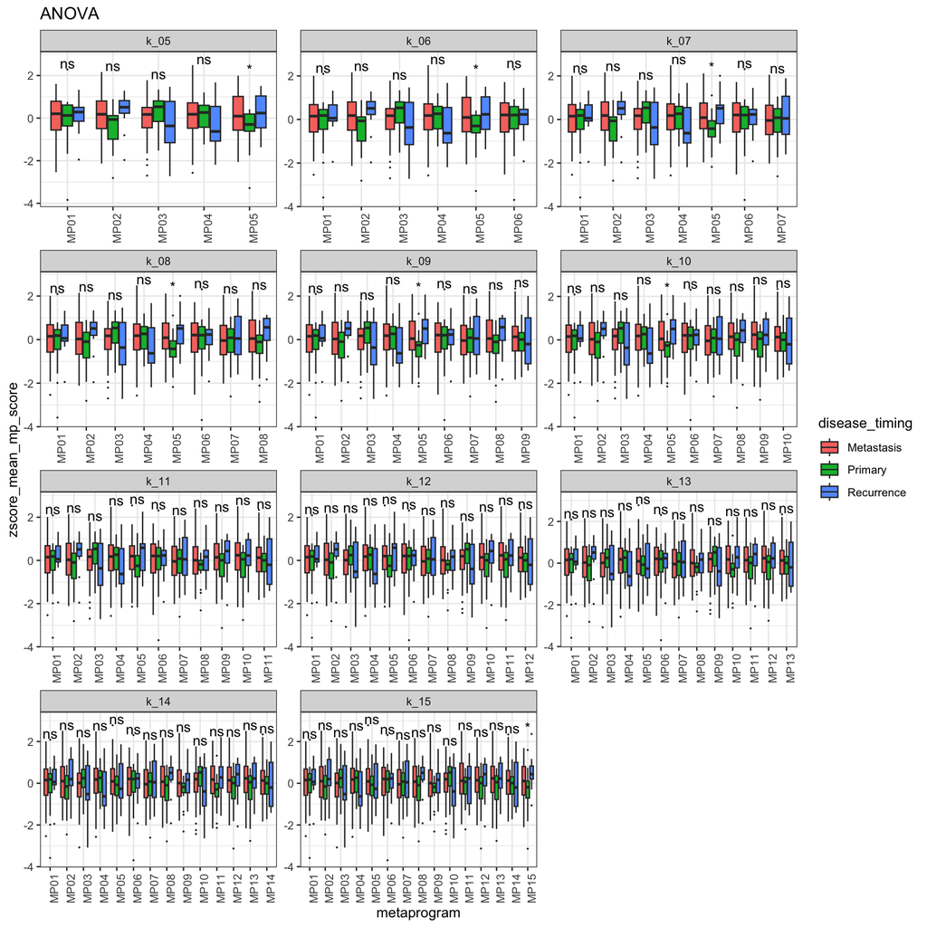

```r
ggplot(mean_scores_df, aes(x = metaprogram, y = zscore_mean_mp_score, fill = disease_timing)) +
  geom_boxplot(outlier.size = 0.1) +
  geom_text(
    data = plain_lmm_results,
    aes(x = metaprogram, y = max_mean_score + 0.3, label = p_adj_signif),
    inherit.aes = FALSE
  ) +
  facet_wrap(vars(n_metaprograms),
             scales = "free",
             ncol = 3) +
  labs(
    title = "ANOVA"
  ) +
  theme(
    axis.text.x = element_text(angle = 90)
  )
```

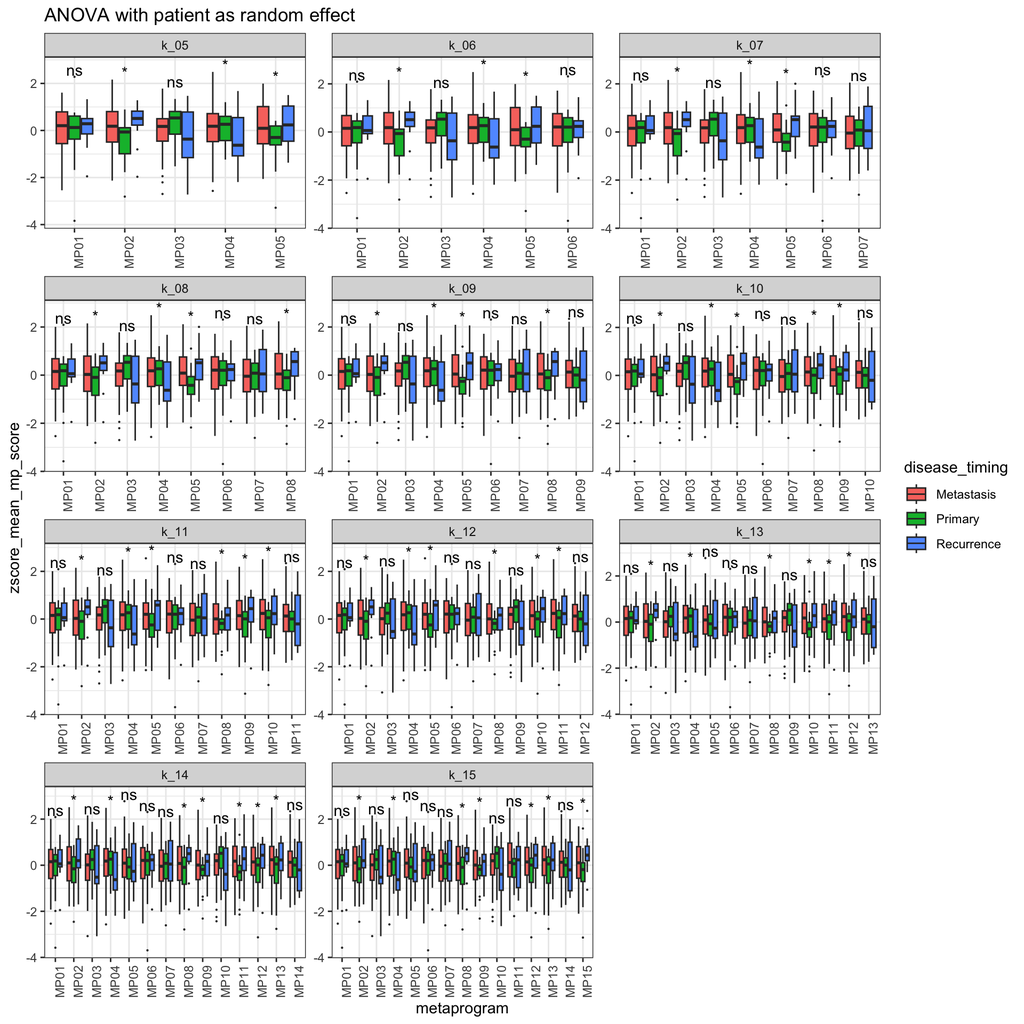

```r
ggplot(mean_scores_df, aes(x = metaprogram, y = zscore_mean_mp_score, fill = disease_timing)) +
  geom_boxplot(outlier.size = 0.1) +
  geom_text(
    data = random_effect_lmm_results,
    aes(x = metaprogram, y = max_mean_score + 0.3 , label = p_adj_signif),
    inherit.aes = FALSE
  ) +
  facet_wrap(vars(n_metaprograms),
             scales = "free",
             ncol = 3) +
  labs(
    title = "ANOVA with patient as random effect"
  ) +
  theme(
    axis.text.x = element_text(angle = 90)
  )
```

Interestingly when we consider patient as random effect, accounting for similarities in gene expression across samples from the same patient, we see a number of metaprograms with significantly different scores when comparing primary vs. metastasis vs. recurrence.

I don’t think this should go into our decision on what makes a “good” metaprogram, but it is useful information to know and I think could be important to show in the summary report.

This also does not tell us about the actual populations of cells within each sample that may have higher or lower scores than other cells within the same sample as it is summarized on a sample level. Further analysis is needed to look at individual cell populations that is outside the scope of our work here. I do think this is a nice starting point for SKC investigators to dig further into when looking at the results from the overall metaprogram analysis.

## Conclusions

- I think we should include the proportion of metaprograms with a CV > null distribution as a metric that helps choose the optimal value of k.
- We should include a summary plot that looks at the distribution of scores across disease timing in the report as extra information about the potential biological meaning of some of these metaprograms.